# Estudio de ejemplo: publicación en línea

Este notebook demuestra todo lo que se puede publicar en línea: **texto**, **código**, **tablas**, **fórmulas**, **imágenes**, **GIFs** y **videos**.

Para publicarlo:

- **Solo lectura**: súbelo a GitHub y ábrelo en nbviewer.org, o conviértelo con [Quarto](https://quarto.org) y publícalo en GitHub Pages/Netlify.
- **Interactivo**: súbelo a Google Colab o usa [Binder](https://mybinder.org).

## 1. Fórmulas (LaTeX)

Fórmula en línea: $E = mc^2$ y la famosa ecuación de Black-Scholes:

$$ C(S, t) = S \cdot N(d_1) - K e^{-r(T-t)} \cdot N(d_2) $$

donde

$$ d_1 = \frac{\ln(S/K) + (r + \sigma^2/2)(T-t)}{\sigma \sqrt{T-t}}, \qquad d_2 = d_1 - \sigma \sqrt{T-t} $$

## 2. Tabla en Markdown

| Producto | Precio (USD) | Cantidad | Total |
| --- | --- | --- | --- |
| Manzanas | 1.20 | 10 | 12.00 |
| Pan | 2.50 | 4 | 10.00 |
| Leche | 1.80 | 6 | 10.80 |
| **Total** |  |  | **32.80** |

```python
import numpy as np
import pandas as pd
import matplotlib.pyplot as plt

print('¡Hola! Esto es código Python ejecutado en el notebook.')
```

```
¡Hola! Esto es código Python ejecutado en el notebook.
```

```python
df = pd.DataFrame({
    'Producto': ['Manzanas', 'Pan', 'Leche'],
    'Precio': [1.20, 2.50, 1.80],
    'Cantidad': [10, 4, 6]
})
df['Total'] = df['Precio'] * df['Cantidad']
df
```

|  | Producto | Precio | Cantidad | Total |
| --- | --- | --- | --- | --- |
| 0 | Manzanas | 1.2 | 10 | 12.0 |
| 1 | Pan | 2.5 | 4 | 10.0 |
| 2 | Leche | 1.8 | 6 | 10.8 |

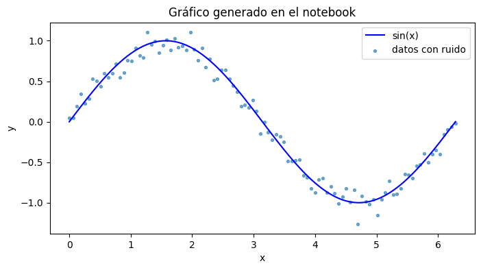

```python
np.random.seed(42)
x = np.linspace(0, 2 * np.pi, 100)
y = np.sin(x) + np.random.normal(0, 0.1, x.size)

fig, ax = plt.subplots(figsize=(8, 4))
ax.plot(x, np.sin(x), 'b-', label='sin(x)')
ax.scatter(x, y, s=8, alpha=0.6, label='datos con ruido')
ax.set_title('Gráfico generado en el notebook')
ax.set_xlabel('x')
ax.set_ylabel('y')
ax.legend()
plt.show()
```

## 3. Imagen local

Guarda la imagen en la misma carpeta que el notebook y refiérela con ruta relativa:

[figure not shown]

*(Crea la carpeta `media/` y pon ahí tus imágenes y GIFs.)*

## 4. GIF animado

Los GIFs se muestran igual que las imágenes. Puedes descargar uno gratis de giphy.com o tenor.com:

[figure not shown]

También se pueden mostrar GIFs alojados en internet por URL:

[figure not shown]

## 5. Video (YouTube)

Los videos se incrustan con HTML en una celda Markdown. Reemplaza el ID `dQw4w9WgXcQ` por el de tu video:

[video not shown]

> **Nota**: nbviewer, Quarto y GitHub Pages permiten iframes. GitHub (vista previa del repo) no los renderiza; por eso es mejor usar nbviewer para este notebook.

## 6. Código con salida de texto

Los resultados de ejecución se publican automáticamente en nbviewer/Quarto si el notebook ya fue ejecutado antes de subirlo:

```python
n = 10
fib = [0, 1]
for _ in range(n - 2):
    fib.append(fib[-1] + fib[-2])
print('Primeros', n, 'números de Fibonacci:', fib)
```

```
Primeros 10 números de Fibonacci: [0, 1, 1, 2, 3, 5, 8, 13, 21, 34]
```

## 7. Regresión lineal

Ajustamos un modelo de regresión lineal $y = a \cdot x + b$ a datos simulados con `numpy`:

```python
np.random.seed(7)
x = np.linspace(0, 10, 50)
y_true = 2.5 * x + 4.0
y = y_true + np.random.normal(0, 1.5, x.size)

a, b = np.polyfit(x, y, 1)
y_pred = a * x + b

ss_res = np.sum((y - y_pred) ** 2)
ss_tot = np.sum((y - np.mean(y)) ** 2)
r2 = 1 - ss_res / ss_tot

print(f'Pendiente (a) = {a:.4f}')
print(f'Intercepto (b) = {b:.4f}')
print(f'R^2 = {r2:.4f}')
```

```
Pendiente (a) = 2.4795
Intercepto (b) = 3.9623
R^2 = 0.9527
```

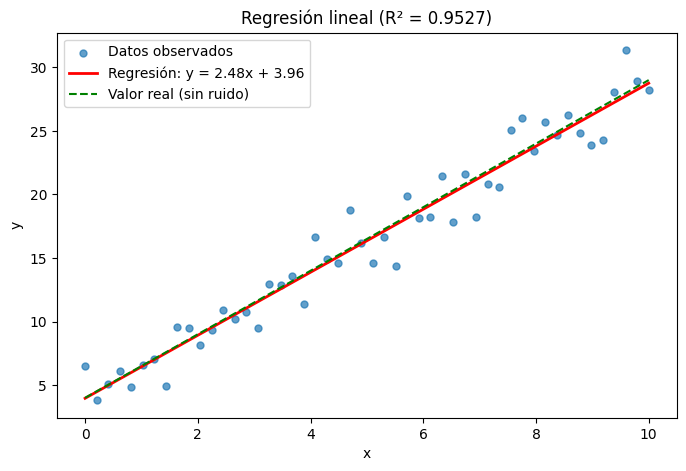

```python
fig, ax = plt.subplots(figsize=(8, 5))
ax.scatter(x, y, s=25, alpha=0.7, label='Datos observados')
ax.plot(x, y_pred, 'r-', linewidth=2, label=f'Regresión: y = {a:.2f}x + {b:.2f}')
ax.plot(x, y_true, 'g--', linewidth=1.5, label='Valor real (sin ruido)')
ax.set_title(f'Regresión lineal (R² = {r2:.4f})')
ax.set_xlabel('x')
ax.set_ylabel('y')
ax.legend()
plt.show()
```

```python
pred_df = pd.DataFrame({'x': [2.0, 5.0, 8.0, 10.0]})
pred_df['y_predicho'] = a * pred_df['x'] + b
pred_df
```

|  | x | y_predicho |
| --- | --- | --- |
| 0 | 2.0 | 8.921372 |
| 1 | 5.0 | 16.359916 |
| 2 | 8.0 | 23.798459 |
| 3 | 10.0 | 28.757488 |